# 05 – XCL1 relay, CD8αα(I) → DC1/aDC1: fetal versus postnatal networks

What the two CausalCCC runs say about the claim, and how they differ with age, with the drawings of the networks

Author

Jeanne Leclerc, Minh Le

Published

October 18, 2026

## Question

Notebook 04 built two CausalCCC networks with MIIC, one per age class, with the same 25 L–R pairs (27 gene–gene links) and the same settings:

|  | Fetal (7–17 PCW) | Postnatal (3 months – 35 years) |
| --- | --- | --- |
| Senders | CD8αα(I) 1,000 cells, 14 donors | CD8αα(I) 1,000 cells, 8 donors |
| Receivers | DC1 300 + aDC1 100 | DC1 300 + aDC1 35 |
| Metadata | senders: donor, chemistry, depth · receivers: population, donor, chemistry, depth | same |

Thymus case 2 pooled NK and CD8αα(I) senders and all ages. There, XCL1 depended only on XCL2 and on the NK / CD8αα(I) label, and the drop of XCL1 at birth in CD8αα(I) cells (29% → 12% of cells, notebook 01) did not show in the network. Here the claim of Park *et al.* is read with **CD8αα(I) cells only** as senders, the cell type it names:

> “GNG4⁺CD8αα⁺ T(I) cells expressed XCL1, which may be involved in the recruitment of XCR1-expressing DC1 cells. […] XCL1 is expressed most highly by CD8αα⁺ T(I) cells […] where these cells are activated and up-regulate CCR7.”

Here we ask:

1. Within CD8αα(I) cells, what does XCL1 depend on, and is it the same before and after birth (section 2)?
2. On the receiver side, is the XCR1 / CCR7 picture of case 2 found in both age classes (section 3)?
3. Which other L–R links have a learned context, and does it change with age (section 4)?
4. How similar are the two networks, and what do depth and donor do in each (sections 1, 5 and 6)?

The networks are read as in case 2 (notebook 05): within each group a link means that two variables stay dependent whatever other variable of the group is conditioned on; the L–R links between the groups are given, not learned.

## Setup

```r
library(tidyverse)

root <- getwd()
while (!file.exists(file.path(root, "scripts", "helpers.R"))) {
  if (dirname(root) == root) stop("Repository root not found.")
  root <- dirname(root)
}
# link_name(), neighbors_of(), graph_distance(), column_cell_type(), network_data(), plot_network_*()
source(file.path(root, "scripts", "helpers.R"))

res_dir <- file.path(root, "results", "thymus_case3_xcl1_age")
out_dir <- file.path(res_dir, "05_interpretation")
fig_dir <- file.path(root, "results", "figures", "thymus_case3_xcl1_age")
dir.create(out_dir, recursive = TRUE, showWarnings = FALSE)
dir.create(fig_dir, recursive = TRUE, showWarnings = FALSE)

RUNS <- c("fetal", "postnatal")
SEND <- "CD8αα(I)"
RECV <- "DC1/aDC1"
META <- c("population", "donor", "method", "n_counts")

read_run <- function(run) {
  dir    <- file.path(res_dir, "04_causalccc", run)
  result <- readRDS(file.path(dir, "miic_input", "miic_result.rds"))
  mosaic <- read_csv(file.path(dir, "causalccc_files", "causalCCC_df.csv"), show_col_types = FALSE, guess_max = Inf)
  lr     <- read_tsv(file.path(dir, "causalccc_files", "causalCCC_interactEdges.tsv"), show_col_types = FALSE)
  # Cell type of each variable: the group whose rows hold its values
  row_type <- if_else(!is.na(mosaic$donor_senders), SEND, RECV)
  type_of  <- column_cell_type(mosaic, row_type)
  lr_links <- link_name(lr$ligands, lr$receptors)
  # One row per pair of variables (MIIC lists each given L-R link twice, once per direction)
  edges <- result$all.edges.summary |>
    filter(type == "P") |>
    distinct(pair_a = pmin(x, y), pair_b = pmax(x, y), .keep_all = TRUE) |>
    select(-pair_a, -pair_b) |>
    mutate(is_lr = link_name(x, y) %in% lr_links,
           where = case_when(is_lr ~ "L–R (given)", type_of[x] == SEND ~ "within senders", .default = "within receivers"))
  list(run = run, result = result, mosaic = mosaic, lr = lr, lr_links = lr_links, row_type = row_type,
       type_of = type_of, edges = edges, intra = filter(edges, !is_lr))
}
nets <- set_names(map(RUNS, read_run), RUNS)

# Labels for the tables and drawings: no group suffix, metadata in brackets
var_label <- function(v) {
  label <- str_remove(v, "_(senders|receivers)$")
  if_else(label %in% META, paste0("[", label, "]"), label)
}
degree_of <- function(net, v) map_int(v, \(g) sum(net$intra$x == g | net$intra$y == g))
neighbour_string <- function(net, v, n = Inf) {
  nb <- net$intra |> filter(x == v | y == v) |>
    transmute(other = if_else(x == v, y, x), info_shifted) |> arrange(desc(info_shifted)) |> head(n)
  if (nrow(nb) == 0) return("–")
  paste0(var_label(nb$other), " (", round(nb$info_shifted), ")", collapse = ", ")
}
```

## 1. Overview of the two networks

```r
map(nets, \(n) {
  vars <- tibble(variable = names(n$mosaic), group = n$type_of[names(n$mosaic)],
                 kind = if_else(str_remove(names(n$mosaic), "_(senders|receivers)$") %in% META, "metadata", "gene"))
  linked <- unique(c(n$edges$x, n$edges$y))
  vars |> group_by(where = if_else(group == SEND, "within senders", "within receivers")) |>
    summarise(genes = sum(kind == "gene"), metadata = sum(kind == "metadata"),
              variables_linked = sum(variable %in% linked)) |>
    left_join(n$edges |> group_by(where) |>
                summarise(links = n(), oriented = sum(abs(infOrt) == 2), genuine_causations = sum(is_causal == "Y")),
              by = "where")
}) |> list_rbind(names_to = "run") |> arrange(desc(where), run)
```

```
# A tibble: 4 × 8
  run    where genes metadata variables_linked links oriented genuine_causations
  <chr>  <chr> <int>    <int>            <int> <int>    <int>              <int>
1 fetal  with…   139        3              142   307       28                  8
2 postn… with…   145        3              148   284       19                  2
3 fetal  with…   134        4              138   251       22                  2
4 postn… with…   153        4              157   340       14                  0
```

**Hubs**: the variables with the most learned links in each group and run.

```r
map(nets, \(n) {
  tibble(variable = unique(c(n$intra$x, n$intra$y))) |>
    mutate(group = n$type_of[variable], degree = degree_of(n, variable)) |>
    group_by(group) |> slice_max(degree, n = 10, with_ties = FALSE) |>
    mutate(rank = row_number(), label = paste0(var_label(variable), " (", degree, ")")) |>
    ungroup() |> select(group, rank, label)
}) |> list_rbind(names_to = "run") |>
  pivot_wider(names_from = c(group, run), values_from = label, names_sep = " · ")
```

```
# A tibble: 10 × 5
    rank `CD8αα(I) · fetal` `DC1/aDC1 · fetal` `CD8αα(I) · postnatal`
   <int> <chr>              <chr>              <chr>
 1     1 [n_counts] (78)    [n_counts] (34)    [n_counts] (58)
 2     2 PPIA (19)          LAMP3 (12)         EEF1A1 (30)
 3     3 EEF1A1 (18)        ARHGDIB (11)       [method] (19)
 4     4 PFN1 (17)          HLA-DPA1 (10)      GAPDH (19)
 5     5 GAPDH (11)         [population] (9)   MIF (13)
 6     6 PARK7 (11)         GAPDH (8)          PARK7 (11)
 7     7 FAU (9)            GNB2L1 (8)         [donor] (9)
 8     8 ATP5E (9)          EEF1A1 (8)         XCL1 (9)
 9     9 NPM1 (9)           PFN1 (8)           YBX1 (9)
10    10 MIF (8)            CPVL (8)           PPIA (7)
# ℹ 1 more variable: `DC1/aDC1 · postnatal` <chr>
```

**How similar are the two networks?** The gene selection was made separately in each run, so the networks share only part of their variables. Among the links whose two variables are in both networks, how many are found in both?

```r
map(c("within senders", "within receivers"), \(w) {
  a <- nets$fetal$intra |> filter(where == w)
  b <- nets$postnatal$intra |> filter(where == w)
  shared_vars <- intersect(names(nets$fetal$mosaic)[nets$fetal$type_of == if_else(w == "within senders", SEND, RECV)],
                           names(nets$postnatal$mosaic)[nets$postnatal$type_of == if_else(w == "within senders", SEND, RECV)])
  la <- link_name(a$x, a$y)[a$x %in% shared_vars & a$y %in% shared_vars]
  lb <- link_name(b$x, b$y)[b$x %in% shared_vars & b$y %in% shared_vars]
  tibble(where = w, shared_variables = length(shared_vars), links_fetal = length(la), links_postnatal = length(lb),
         in_both = length(intersect(la, lb)), jaccard = round(length(intersect(la, lb)) / length(union(la, lb)), 2))
}) |> list_rbind()
```

```
# A tibble: 2 × 6
  where            shared_variables links_fetal links_postnatal in_both jaccard
  <chr>                       <int>       <int>           <int>   <int>   <dbl>
1 within senders                 61          85              77      38    0.31
2 within receivers               84         113             112      40    0.22
```

**Reading.** - **Sizes:** both networks have about 140 genes per group. - Fetal: 307 links among the senders and 251 among the receivers, with 10 genuine causations. - Postnatal: 284 and 340 links, with 2 genuine causations. - **Hubs:** - Sequencing depth `[n_counts]` is the first hub of every group (fetal 78 and 34 links; postnatal 58 and 42). - Among the senders it is followed by housekeeping and metabolic genes (EEF1A1, PPIA, GAPDH, PARK7, MIF). - In the postnatal senders, `[method]` (19 links) and **XCL1 (9 links)** are also hubs. - **The two networks differ a lot:** - The gene selection was made separately in each run, so only 61 sender variables and 84 receiver variables are common to both. - Among the links between these common variables, few are found in both runs (Jaccard index 0.31 among the senders, 0.22 among the receivers). - Comparisons between the runs are therefore made gene by gene, on the genes of the claim.

## 2. Senders: what XCL1 depends on, before and after birth

```r
expand_grid(run = RUNS, variable = c("XCL1", "XCL2")) |>
  mutate(degree = map2_int(run, variable, \(r, v) degree_of(nets[[r]], v)),
         neighbours = map2_chr(run, variable, \(r, v) neighbour_string(nets[[r]], v))) |>
  arrange(variable, run)
```

```
# A tibble: 4 × 4
  run       variable degree neighbours
  <chr>     <chr>     <int> <chr>
1 fetal     XCL1          7 TNFRSF9 (252), XCL2 (221), CRTAM (51), SOD1 (24), Z…
2 postnatal XCL1          9 PARK7 (110), TNFRSF9 (109), XCL2 (90), MAOB (87), M…
3 fetal     XCL2          2 XCL1 (221), TMSB10 (12)
4 postnatal XCL2          3 XCL1 (90), STAM (18), MAOB (5)
```

```r
# XCL1 and XCL2 in the sender cells of each run, per donor (raw counts of the mosaic table)
map(nets, \(n) {
  n$mosaic |> filter(n$row_type == SEND) |>
    group_by(donor = donor_senders) |>
    summarise(cells = n(), XCL1_detected = mean(XCL1 > 0), XCL1_mean = mean(XCL1), XCL2_detected = mean(XCL2 > 0),
              median_depth = median(n_counts_senders), .groups = "drop")
}) |> list_rbind(names_to = "run") |>
  filter(cells >= 20) |>
  mutate(across(where(is.double), \(v) round(v, 2)))
```

```
# A tibble: 19 × 7
   run       donor cells XCL1_detected XCL1_mean XCL2_detected median_depth
   <chr>     <chr> <int>         <dbl>     <dbl>         <dbl>        <dbl>
 1 fetal     C41      28          0.18     19.0           0.07        7240
 2 fetal     F21      36          0.31     19.9           0.17        7718.
 3 fetal     F23      29          0.21     11.5           0.14        4904
 4 fetal     F29     132          0.3       8.8           0.12        3992
 5 fetal     F30     144          0.28     11.9           0.11        5820.
 6 fetal     F38      67          0.27     13.4           0.12        5038
 7 fetal     F41      54          0.44     12.1           0.3         4685
 8 fetal     F45      68          0.31     23.7           0.21        6058.
 9 fetal     F64      80          0.34     16.2           0.21        4210.
10 fetal     F67     233          0.27     13.8           0.18        4000
11 fetal     F74      83          0.25     28.4           0.19        6169
12 fetal     F83      30          0.4      11.1           0.1         5031
13 postnatal A16     149          0.06      1.34          0.01        2919
14 postnatal P1       93          0.23      2.96          0.11        2693
15 postnatal P2      114          0.17      1.18          0.06        2736.
16 postnatal P3      144          0.12      1.03          0.03        2572.
17 postnatal T03      55          0.05      0.6           0           2509
18 postnatal T06     343          0.11      2.48          0.05        2975
19 postnatal T07      90          0.11      4.36          0.07        3140.
```

```r
# XCL1 among XCL2+ and XCL2- cells, and distance from XCL1 to the design variables
map(nets, \(n) {
  s <- n$mosaic |> filter(n$row_type == SEND)
  d <- graph_distance(n$intra |> filter(where == "within senders"), "XCL1")
  tibble(cells = nrow(s), XCL1_detected = mean(s$XCL1 > 0),
         `XCL1+ among XCL2+` = mean(s$XCL1[s$XCL2 > 0] > 0), `XCL1+ among XCL2-` = mean(s$XCL1[s$XCL2 == 0] > 0),
         links_to_donor = d["donor_senders"], links_to_chemistry = d["method_senders"], links_to_depth = d["n_counts_senders"])
}) |> list_rbind(names_to = "run") |>
  mutate(across(where(is.double), \(v) round(v, 2)))
```

```
# A tibble: 2 × 8
  run       cells XCL1_detected `XCL1+ among XCL2+` `XCL1+ among XCL2-`
  <chr>     <int>         <dbl>               <dbl>               <dbl>
1 fetal      1000          0.29                0.96                0.16
2 postnatal  1000          0.12                0.92                0.08
# ℹ 3 more variables: links_to_donor <dbl>, links_to_chemistry <dbl>,
#   links_to_depth <dbl>
```

**Reading.** - **XCL1 is linked to TNFRSF9 (4-1BB / CD137) in both age classes:** it is the strongest XCL1 neighbour in fetal cells (252, before XCL2, 221) and the second in postnatal cells (109). - TNFRSF9 is induced in T cells by TCR signalling. - Its other neighbours point to the same activation program: BIRC3, DUSP4 and MEF2C in fetal cells, BHLHE40 and RGS16 (two genes induced by TCR signalling) in postnatal cells. - CRTAM, the other XCL-associated ligand, is linked to XCL1 in fetal cells and to BHLHE40 and RGS16 in postnatal cells. - **Within CD8αα(I) cells, XCL1 is therefore part of an activation program.** This was hidden in case 2, where NK cells dominated the XCL1 signal. - **XCL2 goes with XCL1 at both ages:** 96% (fetal) and 92% (postnatal) of XCL2⁺ cells express XCL1, against 16% and 8% of XCL2⁻ cells. - **The design variables are not direct neighbours of XCL1** in either run (donor, chemistry, depth). Postnatally, XCL1 also links to PARK7, MAOB and MEST, metabolic genes whose meaning here is unclear. - **The drop at birth is not a depth artefact:** - Postnatal cells are shallower (median 2,500–3,100 counts per donor, against 4,000–7,700 in fetal donors). - But XCL1 falls much more than depth: from 9–28 mean counts per fetal donor to 0.6–4.4 per postnatal donor. - On the normalised scale, the drop is about threefold (notebook 01). - **GNG4 was not selected** in either network, so the “GNG4⁺” part of the claim rests on co-expression only (notebook 01: 59% of fetal GNG4⁺ CD8αα(I) cells express XCL1).

## 3. Receivers: XCR1, CCR7 and the activation of DC1

```r
expand_grid(variable = c("XCR1", "CCR7", "LAMP3", "CD40", "CD80", "population"), run = RUNS) |>
  mutate(degree = map2_int(run, variable, \(r, v) degree_of(nets[[r]], v)),
         neighbours = map2_chr(run, variable, \(r, v) neighbour_string(nets[[r]], v)))
```

```
# A tibble: 12 × 4
   variable   run       degree neighbours
   <chr>      <chr>      <int> <chr>
 1 XCR1       fetal          1 FGL2 (73)
 2 XCR1       postnatal      2 FGL2 (43), HLA-DQA1 (42)
 3 CCR7       fetal          8 [population] (155), BIRC3 (125), SAMSN1 (105), N…
 4 CCR7       postnatal      6 [population] (60), SAMSN1 (57), EBI3 (52), NRP2 …
 5 LAMP3      fetal         12 [population] (142), KDM2B (132), CD40 (124), MGL…
 6 LAMP3      postnatal      4 [population] (63), MGLL (47), FSCN1 (38), TXN (1…
 7 CD40       fetal          5 LAMP3 (124), FSCN1 (120), SRGN (114), CCR7 (10),…
 8 CD40       postnatal      2 BCL2A1 (48), MARCKSL1 (47)
 9 CD80       fetal          2 LAMP3 (105), SRGN (8)
10 CD80       postnatal      3 TXN (30), SLCO5A1 (28), FSCN1 (6)
11 population fetal          9 CCR7 (155), LAMP3 (142), LAD1 (134), CPVL (111),…
12 population postnatal      7 LAMP3 (63), CCR7 (60), ARHGDIB (49), ANKRD33B (3…
```

```r
map(nets, \(n) {
  d <- graph_distance(n$intra |> filter(where == "within receivers"), "XCR1")
  tibble(to = c("population", "CCR7", "LAMP3", "CD40", "CD80", "IL12B"), links_from_XCR1 = unname(d[to]))
}) |> list_rbind(names_to = "run") |>
  pivot_wider(names_from = run, values_from = links_from_XCR1)
```

```
# A tibble: 6 × 3
  to         fetal postnatal
  <chr>      <dbl>     <dbl>
1 population     2         4
2 CCR7           3         5
3 LAMP3          3         5
4 CD40           4         5
5 CD80           4         6
6 IL12B          3         6
```

```r
map(nets, \(n) {
  n$mosaic |> filter(n$row_type == RECV) |>
    mutate(XCR1 = if_else(XCR1 > 0, "XCR1+", "XCR1-"), CCR7 = if_else(CCR7 > 0, "CCR7+", "CCR7-")) |>
    count(population, XCR1, CCR7) |>
    pivot_wider(names_from = c(XCR1, CCR7), values_from = n, values_fill = 0)
}) |> list_rbind(names_to = "run")
```

```
# A tibble: 4 × 6
  run       population `XCR1+_CCR7+` `XCR1+_CCR7-` `XCR1-_CCR7+` `XCR1-_CCR7-`
  <chr>     <chr>              <int>         <int>         <int>         <int>
1 fetal     DC1                    6           166             5           123
2 fetal     aDC1                   2             0            88            10
3 postnatal DC1                    6           140            12           142
4 postnatal aDC1                   1             0            30             4
```

**Reading.** - **XCR1 has only DC1 neighbours:** FGL2 in both runs, and HLA-DQA1 postnatally. Unlike case 2, it is not directly linked to `[population]`: that link was weak in case 2 (16) and is lost with 300 DC1 instead of 500. - **CCR7 and LAMP3 stay tied to the DC1 / aDC1 label at both ages:** 155 and 142 in fetal cells, 60 and 63 in postnatal cells. The links are weaker postnatally because there are only 35 aDC1. - **The activation program around LAMP3 differs with age.** In fetal cells, LAMP3 is linked to CD40 and CD80 (as in case 2); in postnatal cells it is not. There, CD40 is linked to BCL2A1 and MARCKSL1 instead. - **XCR1 and CCR7 remain almost mutually exclusive:** - fetal: 172 of 300 DC1 express XCR1 and 11 express CCR7; 90 of 100 aDC1 express CCR7 and 2 express XCR1; - postnatal: 146 of 300 DC1 express XCR1 and 18 express CCR7; 31 of 35 aDC1 express CCR7 and 1 expresses XCR1. - **Conclusion for the receivers:** the picture of case 2 holds at both ages. XCR1 marks resting DC1, CCR7 and LAMP3 mark activated DC1, and the activation genes do not depend on XCR1.

## 4. The L–R links, fetal and postnatal

For every given link, the learned context of the ligand (in CD8αα(I) cells) and of the receptor (in DC1 / aDC1 cells) in each run. On the receiver side, a receptor linked to `[population]` is specific to DC1 or to aDC1. On the sender side there is no population variable (one population): a ligand linked only to `[donor]`, `[method]` or `[n_counts]` varies for technical or donor reasons; a ligand with gene neighbours belongs to a program of the cell.

```r
lr_context <- map(nets, \(n) {
  n$lr |>
    mutate(ligand = var_label(ligands), receptor = var_label(receptors),
           ligand_degree = degree_of(n, ligands), receptor_degree = degree_of(n, receptors),
           receptor_to_population = map_lgl(receptors, \(g) "population" %in% neighbors_of(g, n$intra)$neighbor),
           ligand_neighbours = map_chr(ligands, \(g) neighbour_string(n, g, n = 3)),
           receptor_neighbours = map_chr(receptors, \(g) neighbour_string(n, g, n = 3)))
}) |> list_rbind(names_to = "run")

lr_context |>
  select(run, ligand, receptor, ligand_degree, ligand_neighbours) |>
  pivot_wider(names_from = run, values_from = c(ligand_degree, ligand_neighbours)) |>
  as.data.frame()
```

```
   ligand receptor ligand_degree_fetal ligand_degree_postnatal
1    XCL1     XCR1                   7                       9
2    XCL2     XCR1                   2                       3
3     MIF     CD74                   8                      13
4     APP     CD74                   4                       4
5     MIF TNFRSF14                   8                      13
6  LGALS9     CD44                   1                       2
7    CD28     CD86                   3                       1
8  CD40LG     CD40                   3                       4
9    CD28     CD80                   3                       1
10    SPN    ICAM1                   2                       1
11  ITGB1    PLAUR                   2                       3
12  ITGA4    PLAUR                   4                       3
13  CRTAM    CADM1                   1                       3
14   CD38   PECAM1                   1                       2
```

[output cut: 69 more lines]

```r
lr_context |>
  distinct(run, receptor, receptor_degree, receptor_to_population, receptor_neighbours) |>
  pivot_wider(names_from = run, values_from = c(receptor_degree, receptor_to_population, receptor_neighbours)) |>
  as.data.frame()
```

```
   receptor receptor_degree_fetal receptor_degree_postnatal
1      XCR1                     1                         2
2      CD74                     6                        11
3  TNFRSF14                     1                         3
4      CD44                     1                         2
5      CD86                     1                         1
6      CD40                     5                         2
7      CD80                     2                         3
8     ICAM1                     2                         4
9     PLAUR                     1                         4
10    CADM1                     1                         3
11   PECAM1                     2                         2
12    CD274                     1                         1
13     LTBR                     1                         2
14  CD200R1                     2                         1
```

[output cut: 73 more lines]

```r
# Context of each ligand gene: isolated, design variables only, or with genes
lr_context |>
  distinct(run, ligands, ligand) |>
  mutate(context = map2_chr(run, ligands, \(r, g) {
    nb <- neighbors_of(g, nets[[r]]$intra)$neighbor
    case_when(length(nb) == 0 ~ "isolated",
              all(str_remove(nb, "_(senders|receivers)$") %in% META) ~ "design variables only",
              .default = "with genes")
  })) |>
  count(run, context) |>
  pivot_wider(names_from = run, values_from = n, values_fill = 0)
```

```
# A tibble: 2 × 3
  context               fetal postnatal
  <chr>                 <int>     <int>
1 with genes               22        20
2 design variables only     0         2
```

**Reading.** - **Almost every ligand has gene neighbours** (fetal 22 of 22, postnatal 20 of 22). The two postnatal exceptions, CD28 and ICAM3, are linked only to `[n_counts]`. - **T-cell costimulation is a fetal feature here:** - In fetal cells, CD28 is linked to PDCD1, and its receptors CD80 and CD40 (ligand CD40LG) are next to LAMP3 on the aDC1 side, as in case 2. - In postnatal cells, CD28 depends only on depth, and CD40 / CD80 have left the LAMP3 module. - CD274 (PD-L1) is tied to the aDC1 label at both ages; PDCD1LG2 (PD-L2) only in fetal cells. - **Other changes with age:** - CRTAM joins the TCR-activation genes postnatally (BHLHE40, RGS16). - CADM1 is linked to CLEC9A (DC1 identity) in fetal cells, to HLA-DPA1 in postnatal cells. - CD6 moves from XCL1 / ARHGDIB (fetal) to the T-cell identity genes CD5 and LEF1 (postnatal). - ITGA4 is tied to `[donor]` postnatally (112). - **Ubiquitous pairs:** MIF → CD74 stays in the housekeeping (PPIA, GAPDH, NME2) and MHC class II modules at both ages, as in cases 1 and 2.

## 5. Design variables and sequencing depth

```r
expand_grid(run = RUNS, variable = c("donor_senders", "method_senders", "n_counts_senders",
                                     "population", "donor_receivers", "method_receivers", "n_counts_receivers")) |>
  mutate(degree = map2_int(run, variable, \(r, v) degree_of(nets[[r]], v)),
         neighbours = map2_chr(run, variable, \(r, v) neighbour_string(nets[[r]], v, n = 8)))
```

```
# A tibble: 14 × 4
   run       variable           degree neighbours
   <chr>     <chr>               <int> <chr>
 1 fetal     donor_senders           6 [method] (284), AC090498.1 (282), ATP5E …
 2 fetal     method_senders          6 [donor] (284), GABARAP (244), LCP2 (92),…
 3 fetal     n_counts_senders       78 FAU (609), UBA52 (577), BTF3 (558), GNB2…
 4 fetal     population              9 CCR7 (155), LAMP3 (142), LAD1 (134), CPV…
 5 fetal     donor_receivers         5 HLA-DRB5 (169), [method] (138), TMSB4X (…
 6 fetal     method_receivers        2 [donor] (138), MIF (38)
 7 fetal     n_counts_receivers     34 FAU (278), UBA52 (265), CFL1 (265), COX4…
 8 postnatal donor_senders           9 [method] (562), AC090498.1 (190), HSPA8 …
 9 postnatal method_senders         19 [donor] (562), ATP6V0C (296), NDUFB8 (22…
10 postnatal n_counts_senders       58 EEF1A1 (371), PTMA (316), FAU (300), HNR…
11 postnatal population              7 LAMP3 (63), CCR7 (60), ARHGDIB (49), ANK…
12 postnatal donor_receivers         5 [method] (153), AC090498.1 (117), HLA-DR…
13 postnatal method_receivers        2 [donor] (153), ATP6V0C (107)
14 postnatal n_counts_receivers     42 HLA-B (206), VIM (204), FAU (202), ATP5E…
```

Genes that follow depth, measured as in case 2 (Spearman correlation with the total counts of the cell within each population, median over the populations of the group, threshold 0.5), and the share of gene–gene links joining two of them.

```r
map(nets, \(n) {
  gene_vars <- names(n$mosaic)[!str_remove(names(n$mosaic), "_(senders|receivers)$") %in% META]
  pop <- if_else(n$row_type == SEND, "CD8αα(I)", n$mosaic$population)
  depth <- coalesce(n$mosaic$n_counts_senders, n$mosaic$n_counts_receivers)
  rho <- map_dbl(gene_vars, \(v) {
    rows <- n$row_type == n$type_of[[v]]
    x <- n$mosaic[[v]][rows]
    r <- tapply(seq_along(x), pop[rows], \(i) if (sd(x[i]) == 0) NA_real_ else cor(x[i], depth[rows][i], method = "spearman"))
    median(unlist(r), na.rm = TRUE)
  }) |> set_names(gene_vars)
  follows <- gene_vars[!is.na(rho) & rho > 0.5]
  n$intra |> filter(x %in% gene_vars, y %in% gene_vars) |>
    group_by(where) |>
    summarise(gene_gene_links = n(), both_follow_depth = sum(x %in% follows & y %in% follows)) |>
    mutate(share = both_follow_depth / gene_gene_links,
           expected_by_chance = map_dbl(where, \(w) {
             g <- gene_vars[n$type_of[gene_vars] == if_else(w == "within senders", SEND, RECV)]
             mean(g %in% follows)^2
           }))
}) |> list_rbind(names_to = "run") |>
  mutate(across(c(share, expected_by_chance), \(v) round(v, 3)))
```

```
# A tibble: 4 × 6
  run       where     gene_gene_links both_follow_depth share expected_by_chance
  <chr>     <chr>               <int>             <int> <dbl>              <dbl>
1 fetal     within r…             202               143 0.708              0.513
2 fetal     within s…             218               129 0.592              0.429
3 postnatal within r…             285               208 0.73               0.555
4 postnatal within s…             199                34 0.171              0.037
```

**Reading.** - **Depth structures both networks.** - In fetal sender cells, most selected genes follow depth: 59% of gene–gene links join two depth-following genes, against 43% by chance. - In postnatal sender cells, the share is 17% against 4%. - Among the receivers, it is 71% and 73% (51% and 56% by chance), as in case 2. - **Postnatally, chemistry and donor are confounded among the senders.** `[method]`–`[donor]` is the strongest link (562), and `[method]` has 19 links. The postnatal donors were sequenced either 3′ (P1–P3) or 5′ (T03, T06, T07, A43), with A16 in both, so a chemistry effect cannot be told apart from a donor effect. - **Fetal donor** links only to a handful of genes (HLA-DRB5 and housekeeping genes), as in case 2. - **None of the claim’s genes is directly linked to donor, chemistry or depth** in either run.

## 6. Orientations and genuine causations

```r
oriented <- map(nets, \(n) {
  n$edges |>
    filter(abs(infOrt) == 2) |>
    transmute(from = if_else(infOrt == 2, x, y), to = if_else(infOrt == 2, y, x), where,
              strength = round(info_shifted), genuine = is_causal,
              involves_metadata = str_detect(paste(from, to), "(population|donor|method|n_counts)"))
}) |> list_rbind(names_to = "run")
oriented |> count(run, where, involves_metadata, genuine)
```

```
         run            where involves_metadata genuine  n
1      fetal within receivers             FALSE       N 15
2      fetal within receivers             FALSE       Y  2
3      fetal within receivers              TRUE       N  5
4      fetal   within senders             FALSE       N 17
5      fetal   within senders             FALSE       Y  1
6      fetal   within senders              TRUE       N  3
7      fetal   within senders              TRUE       Y  7
8  postnatal within receivers             FALSE       N  9
9  postnatal within receivers              TRUE       N  5
10 postnatal   within senders             FALSE       N 11
11 postnatal   within senders              TRUE       N  6
12 postnatal   within senders              TRUE       Y  2
```

```r
oriented |>
  filter(genuine == "Y" | str_detect(paste(from, to), "XCL|XCR1|CCR7|LAMP3")) |>
  mutate(from = var_label(from), to = var_label(to)) |>
  arrange(run, desc(genuine), desc(strength)) |>
  as.data.frame()
```

```
         run       from      to            where strength genuine
1      fetal [n_counts]   UBA52   within senders      577       Y
2      fetal [n_counts]   SUMO2   within senders      399       Y
3      fetal [n_counts]  TMSB10   within senders      325       Y
4      fetal [n_counts] SLC25A5   within senders      309       Y
5      fetal [n_counts]   EIF3K   within senders      304       Y
6      fetal [n_counts]    GNG5   within senders      290       Y
7      fetal [n_counts]    PHB2   within senders      251       Y
8      fetal       CPVL     LYZ within receivers      162       Y
9      fetal       CPVL  CORO1A within receivers       21       Y
10     fetal      ATP5E     FAU   within senders       13       Y
11     fetal      LAMP3    MGLL within receivers      122       N
12 postnatal   [method]   PCBP2   within senders      157       Y
13 postnatal [n_counts]     RAN   within senders      142       Y
   involves_metadata
1               TRUE
2               TRUE
3               TRUE
4               TRUE
5               TRUE
6               TRUE
7               TRUE
8              FALSE
9              FALSE
10             FALSE
11             FALSE
12              TRUE
13              TRUE
```

**Reading.** - **Fetal: 50 links are oriented, and 10 are genuine causations.** - 7 go from `[n_counts]` to housekeeping genes (UBA52, SUMO2, TMSB10, SLC25A5, EIF3K, GNG5, PHB2): depth as a cause of counts, the expected technical direction. - The other 3 are ATP5E → FAU, CPVL → LYZ and CPVL → CORO1A. - **Postnatal: 33 links are oriented, and 2 are genuine causations,** `[method]` → PCBP2 and `[n_counts]` → RAN, both technical. - **No orientation involves XCL1, XCL2, XCR1 or CCR7** in either run.

## 7. The networks, drawn

Same conventions as case 2: colours are the two groups; diamonds are the centres (XCL1, XCL2, XCR1); dashed lines are the given L–R links (drawn thin); an arrowhead is an orientation found by MIIC, and a green link a genuine causation; thicker links are stronger. Metadata variables are in brackets.

```r
# Colours of the two groups for the drawing functions of scripts/helpers.R (which read these two global vectors)
cell_type_colours <- set_names(c("#f2c57c", "#9cc3e6"), c(SEND, RECV))
cell_type_borders <- set_names(c("#a8742a", "#2f6491"), c(SEND, RECV))
centres <- c("XCL1", "XCL2", "XCR1")
claim_nets <- map(nets, \(n) network_data(n$edges, n$lr_links, n$type_of, var_label, centres = centres, max_distance = 2))
map(claim_nets, \(cn) c(variables = nrow(cn$nodes), links = nrow(cn$links))) |> bind_rows(.id = "run")
```

```
# A tibble: 2 × 3
  run       variables links
  <chr>         <int> <int>
1 fetal            28    45
2 postnatal        40    57
```

### The neighbourhood of the claim, fetal

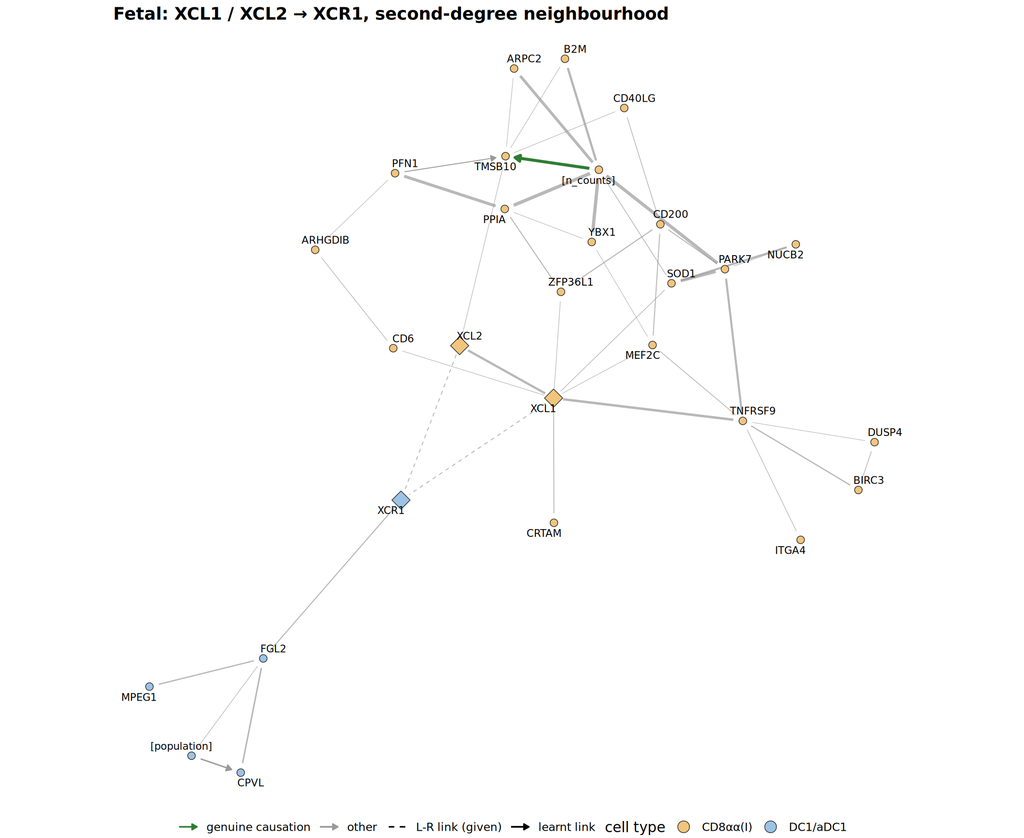

Figure 1

```r
p_fetal <- plot_network_static(claim_nets$fetal, title = "Fetal: XCL1 / XCL2 → XCR1, second-degree neighbourhood",
                               label_size = 2.8)
ggsave(file.path(fig_dir, "05_claim_neighbourhood_fetal.png"), p_fetal, width = 11, height = 9, dpi = 200)
p_fetal
```

```r
plot_network_interactive(claim_nets$fetal, title = "Fetal: second-degree neighbourhood (interactive)", height = "700px")
```

[interactive chart not shown]

Figure 2

### The neighbourhood of the claim, postnatal

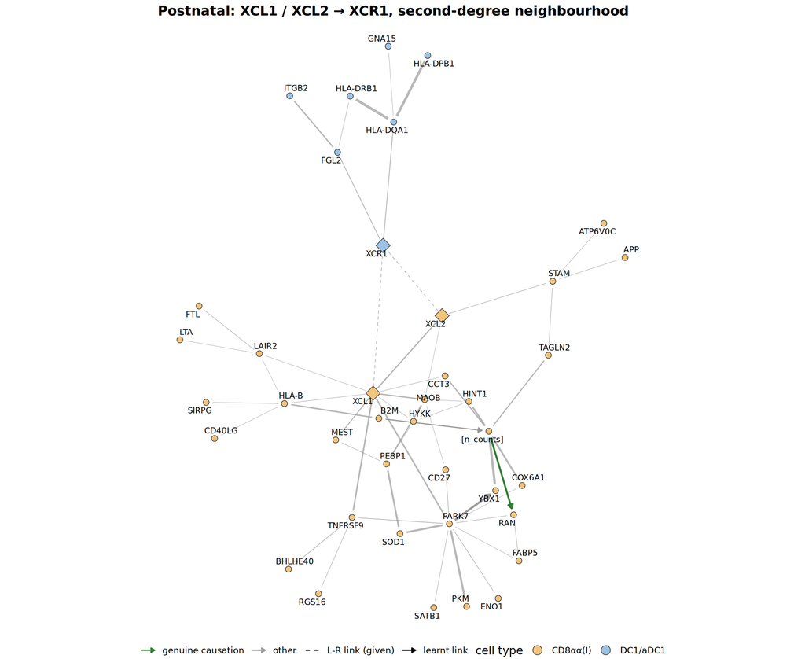

Figure 3

```r
p_postnatal <- plot_network_static(claim_nets$postnatal,
                                   title = "Postnatal: XCL1 / XCL2 → XCR1, second-degree neighbourhood", label_size = 2.8)
ggsave(file.path(fig_dir, "05_claim_neighbourhood_postnatal.png"), p_postnatal, width = 11, height = 9, dpi = 200)
p_postnatal
```

```r
plot_network_interactive(claim_nets$postnatal, title = "Postnatal: second-degree neighbourhood (interactive)",
                         height = "700px")
```

[interactive chart not shown]

Figure 4

### The whole networks

```r
network_data(nets$fetal$edges, nets$fetal$lr_links, nets$fetal$type_of, var_label) |>
  plot_network_interactive(title = "Fetal: all links", height = "800px")
```

[interactive chart not shown]

Figure 5

```r
network_data(nets$postnatal$edges, nets$postnatal$lr_links, nets$postnatal$type_of, var_label) |>
  plot_network_interactive(title = "Postnatal: all links", height = "800px")
```

[interactive chart not shown]

Figure 6

```r
map(nets, \(n) n$edges |>
      transmute(x, y, x_label = var_label(x), y_label = var_label(y), where, is_lr, info_shifted, infOrt, is_causal)) |>
  list_rbind(names_to = "run") |>
  write_csv(file.path(out_dir, "retained_links.csv"))
lr_context |> select(-ligands, -receptors) |> write_csv(file.path(out_dir, "lr_links_context.csv"))
list.files(out_dir)
```

```
[1] "lr_links_context.csv" "retained_links.csv"
```

## 8. What the literature says

Three findings of sections 2 and 4 go beyond the claim of Park *et al.*. For each, what is already published, what the networks add, and what remains untested.

**XCL1 with TNFRSF9 (4-1BB) and TCR-activation genes: plausible, not described as such.**

- **Known:**
  - Human CD8αα⁺ PD-1⁺ thymocytes are selected by a strong (agonist) TCR signal, before conventional selection (Verstichel *et al.*, *Sci Immunol* 2017, [doi:10.1126/sciimmunol.aah4232](https://doi.org/10.1126/sciimmunol.aah4232)).
  - In mice, the thymic precursors of CD8αα intraepithelial lymphocytes carry the program of a recent, strong TCR signal (Ruscher *et al.*, *Nat Immunol* 2017, [doi:10.1038/ni.3751](https://doi.org/10.1038/ni.3751)).
  - In mice, CD8 T cells secrete XCL1 when they recognise their antigen, and XCR1 is restricted to cross-presenting DCs (Dorner *et al.*, *Immunity* 2009, [doi:10.1016/j.immuni.2009.08.027](https://doi.org/10.1016/j.immuni.2009.08.027)). That XCL1 goes with an activation program is therefore expected.
- **Added by the networks:** in human thymic CD8αα(I) cells, XCL1 goes with the 4-1BB⁺ activated fraction (TNFRSF9 is its strongest or second neighbour at both ages), and this fraction is larger before birth. No published study names an XCL1–TNFRSF9 association in these cells.
- **Untested:** whether these cells are the authors’ “T(agonist)” population, and whether they are the GNG4⁺ cells of the claim (GNG4 is not in the networks).

**CRTAM → CADM1: a known pair, here found in the human thymus.**

- **Known:**
  - CRTAM binds CADM1 (Necl2), and the binding makes CRTAM⁺ and CADM1⁺ cells adhere (Arase *et al.*, *Int Immunol* 2005, [doi:10.1093/intimm/dxh299](https://doi.org/10.1093/intimm/dxh299); Galibert *et al.*, *J Biol Chem* 2005, [doi:10.1074/jbc.M502095200](https://doi.org/10.1074/jbc.M502095200)).
  - CADM1 marks the BDCA3⁺ human and CD8α⁺ mouse DCs (Galibert 2005), the DC1 lineage: this agrees with the CADM1–CLEC9A link of the fetal network.
  - CRTAM is induced late after CD8 T-cell activation (Takeuchi *et al.*, *J Immunol* 2009, [doi:10.4049/jimmunol.0901248](https://doi.org/10.4049/jimmunol.0901248)): this agrees with its postnatal neighbours BHLHE40 and RGS16, two genes induced by TCR signalling.
- **Added by the networks:** in the fetal network, CRTAM is linked to XCL1 and CADM1 to CLEC9A, so the pair connects the XCL1⁺ CD8αα(I) cells to DC1 in the human thymus (case 2, all ages pooled, gives CRTAM–XCL2 and CADM1–CLEC9A). Postnatally, CRTAM stays in the activation program (BHLHE40, RGS16) but CADM1 moves to HLA-DPA1. Galibert 2005 proposed a role in the mouse thymus; we found no human thymus data.
- **Untested:** adhesion or signalling between these two cell types; the network shows co-variation only.

## Summary

| Question | Fetal (7–17 PCW) | Postnatal (3 months – 35 years) |
| --- | --- | --- |
| XCL1 in CD8αα(I), sender side | 29% of cells; linked to TNFRSF9 (4-1BB, strongest neighbour), XCL2, CRTAM, near BIRC3 and DUSP4 | 12% of cells, not a depth artefact; linked to TNFRSF9 (second neighbour), near BHLHE40 and RGS16 |
| XCR1 → DC1 activation, receiver side | XCR1 (resting DC1) and CCR7 / LAMP3 (aDC1) almost mutually exclusive; activation genes do not depend on XCR1 | same, with 35 aDC1 only |
| Other L–R links | CD28 → CD80, CD40LG → CD40, PDCD1 → CD274 reach the LAMP3 module; CRTAM → CADM1 connects XCL1⁺ cells to CLEC9A⁺ DC1 | only CD274 (PD-L1) stays tied to aDC1; CRTAM joins the TCR-activation genes, CADM1 moves to HLA-DPA1 |
| Network similarity, design variables | Jaccard 0.31 (senders) and 0.22 (receivers) between runs; depth first hub of every group; donor, chemistry and depth not linked to the claim’s genes | chemistry and donor confounded among the senders |

**What this means for the claim.**

1. **CD8αα(I) cells are an XCL1 source mainly before birth, and it is their activated fraction that produces it.** XCL1 drops at birth (29% → 12% of cells, much more than depth). At both ages it belongs to an activation program (TNFRSF9 / 4-1BB and TCR-induced genes). This refines the claim; it is new but fits the literature on agonist-selected CD8αα cells (section 8). GNG4 is not in the networks, so the “GNG4⁺” part rests on co-expression only.
2. **The relay part reads as in case 2 at both ages:** the networks describe the change of state from XCR1⁺ DC1 to CCR7⁺ aDC1, but do not attribute it to XCL1 signalling.
3. **Costimulation and CRTAM → CADM1 connect CD8αα(I) cells to DC1 in fetal cells.** These are known thymocyte–DC signals; their restriction to fetal life is not described (section 8).

**Limits.** - The two networks rest on different gene selections and share few links, so they are compared gene by gene. - Postnatal aDC1 has only 35 cells. - Postnatally, chemistry and donor are confounded. - As in cases 1 and 2, the L–R links are given, not inferred, and the orientations involving the claim’s genes are not causal.

**Possible next steps.** - Split CD8αα(I) cells into TNFRSF9⁺ and TNFRSF9⁻ and compare their XCL1, XCL2 and GNG4 expression. - Check whether the TNFRSF9⁺ XCL1⁺ CD8αα(I) cells match the authors’ “T(agonist)” population.

**Outputs:** - `results/thymus_case3_xcl1_age/05_interpretation/retained_links.csv`: every link of both runs; - `results/thymus_case3_xcl1_age/05_interpretation/lr_links_context.csv`: the context of each L–R link per run; - `results/figures/thymus_case3_xcl1_age/05_claim_neighbourhood_fetal.png` and `..._postnatal.png`: the static figures.